# Análisis de los resultados del modelado para Máster

En este análisis se realiza un análisis de los resultados obtenidos con el modelo realizado para los alumnos de Máster.

En este sentido, se ha realizado lo siguiente:

1. Se obtienen las métricas del modelo en el conjunto test.
2. Se observa la matriz de confusión para los matriculados y no matriculados, comparando el real con el predicho.
3. Se comparan las tasas de matriculación obtenidas con el predicho y las reales en las 5 principales titulaciones.
4. Se analizan las distribuciones de la probabilidad en cada una de las distintas etapas.
5. Se mira las distribuciones de la probabilidad de matrícula en las 5 titulaciones top.
6. Se mira la importancia de las variables dentro del modelo utilizado.

## 1. Resultados globales del modelo de Máster

```
--------------------------------------------------
      VIRTUDES Y MÉTRICAS DEL MODELO DE ADMISIÓN
--------------------------------------------------
✅ Porcentaje de Acierto (Accuracy): 87.99%
🎯 Capacidad de Discriminación (AUC-ROC): 0.8970
📊 Precisión (Cuando predice Sí, ¿cuánto acierta?): 85.80%
📈 Sensibilidad (¿A cuántos del total captura?): 95.33%
🛡️ Especificidad (Capacidad de detectar No-Matrícula): 77.57%
--------------------------------------------------

ANÁLISIS ESTRATÉGICO:
👍 El modelo es ROBUSTO y fiable para la planificación financiera y de plazas.
💡 De cada 100 matrículas reales, el modelo identifica correctamente a 95 candidatos.
💡 El modelo es especialmente bueno descartando (Especificidad: 77.57%), lo que ahorra esfuerzo comercial.
--------------------------------------------------
```

## 2. Matriz de confusión global

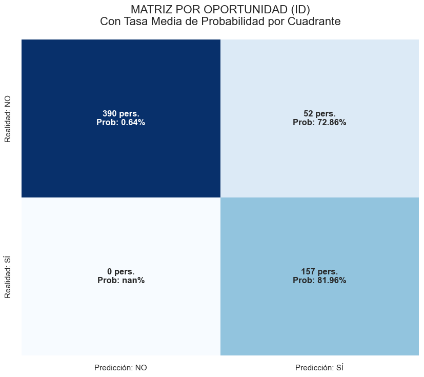

```
Exactitud (Accuracy): 91.32%
Precisión (Certeza de Matrícula): 75.12%
```

Aquí se puede observar que el modelo acierta en el 91% de los casos y que, dentro de los matriculados, acierta en el 75% de los casos. Teniendo en cuenta que tenemos mucha menos muestra de Máster que de grado, los resultados son muy buenos.

## 3. Comparación tasa real de matriculación con la predicha en el top 5 de titulaciones

```
--------------------------------------------------
      VIRTUDES DEL MODELO (SOBRE OPORTUNIDADES ÚNICAS)
--------------------------------------------------
✅ Exactitud Global (Accuracy): 88.81%
🎯 Área bajo la curva (AUC): 0.9382
📊 Precisión de Matrícula: 74.46%
📈 Capacidad de Captación (Recall): 87.26%
--------------------------------------------------
```

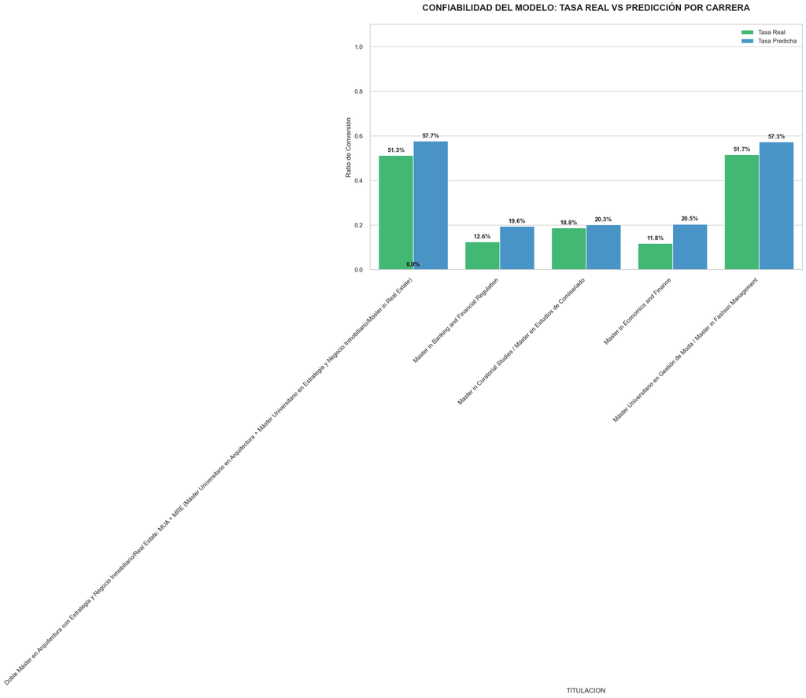

## 4. Evolución de la probabilidad de matrícula por etapa

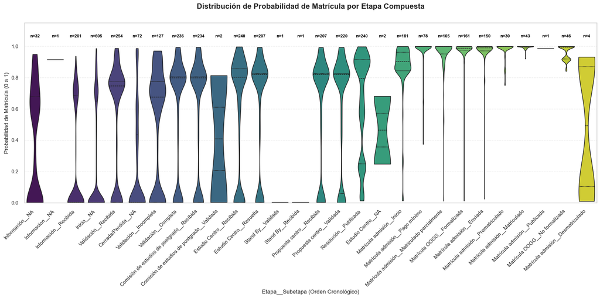

En este gráfico se ve la distribución de la probabilidad dentro de cada Etapa y Subetapa, viendo como en etapas iniciales hay probabilidades muy altas y muy bajas, lo cual srefleja perfectamente la falta de datos. En cambio, a partir de la etapa de pago mínimo, las probabilidades empiezan a ser muy altas, lo que indica que la matrícula es casi inminente.

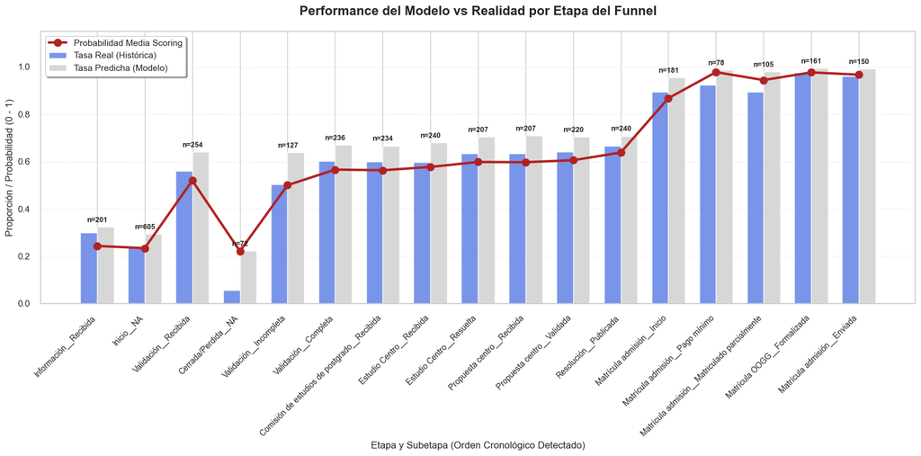

```
📋 RESUMEN DE MÉTRICAS POR ETAPA ORDENADA:
                             etapa_compuesta  tasa_real  prediction_label  prob_matricula_real  num_casos
                       Información__Recibida   0.298507          0.323383             0.243396        201
                                  Inicio__NA   0.241322          0.294215             0.233936        605
                        Validación__Recibida   0.559055          0.641732             0.519681        254
                         Cerrada/Perdida__NA   0.055556          0.222222             0.221358         72
                      Validación__Incompleta   0.503937          0.637795             0.500125        127
                        Validación__Completa   0.601695          0.669492             0.565929        236
 Comisión de estudios de postgrado__Recibida   0.598291          0.666667             0.563140        234
                    Estudio Centro__Recibida   0.595833          0.679167             0.577094        240
                    Estudio Centro__Resuelta   0.632850          0.705314             0.598058        207
                  Propuesta centro__Recibida   0.632850          0.710145             0.597185        207
                  Propuesta centro__Validada   0.640909          0.704545             0.605537        220
                       Resolución__Publicada   0.666667          0.708333             0.637995        240
                  Matrícula admisión__Inicio   0.895028          0.955801             0.867540        181
             Matrícula admisión__Pago mínimo   0.923077          0.987179             0.977794         78
Matrícula admisión__Matriculado parcialmente   0.895238          0.980952             0.944150        105
                 Matrícula OOGG__Formalizada   0.975155          0.993789             0.976635        161
                 Matrícula admisión__Enviada   0.960000          0.993333             0.966967        150
```

Aquí se puede observar las tasas de matriculación por etapa y subetapa ordenadas, junto a la probabilidad media. Se puede ver que a medida que se va avanzando en las distintas etapas, la probabilidad media va aumentando y que una vez se publica la resolución, la probabilidad aumenta considerablemente.

## Distribución de probabilidades en el top 5 de titulaciones

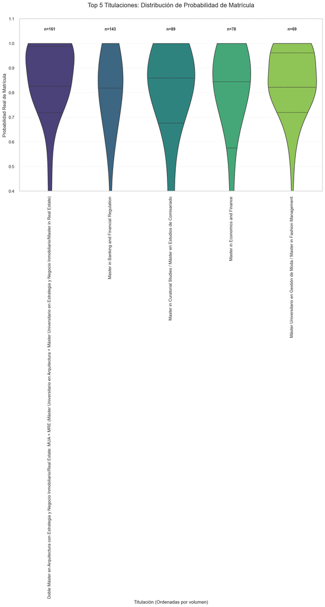

## Importancia de variables

```
Transformation Pipeline and Model Successfully Loaded
```

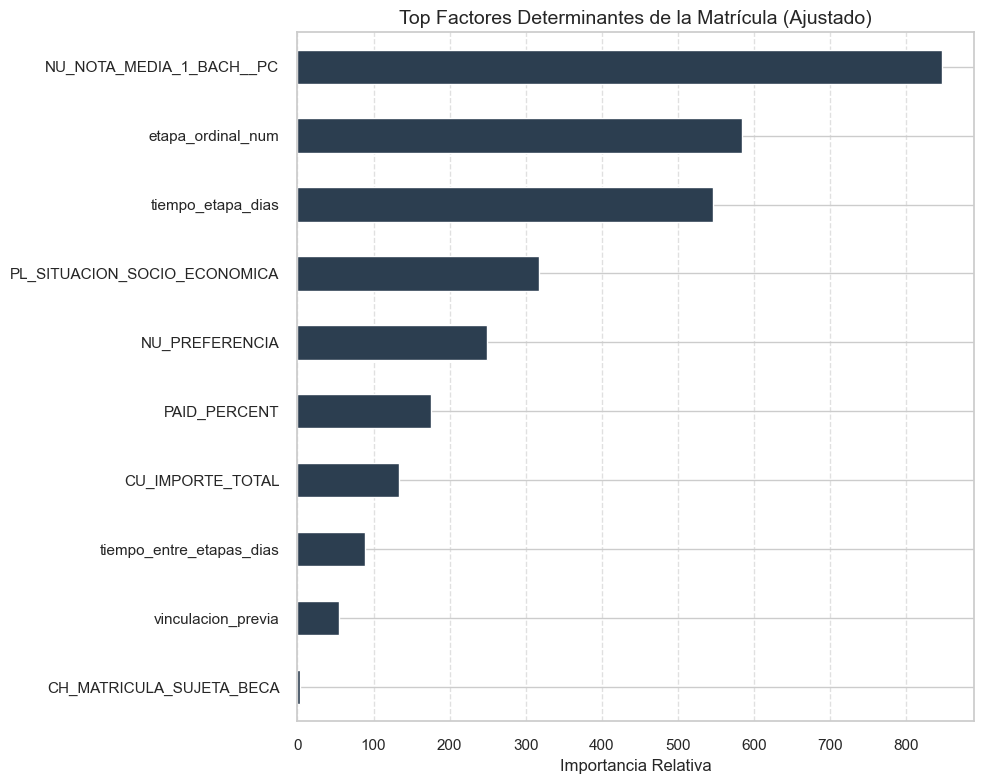

Aquí se puede observar que las variables más importantes reflejan un amplio espectro de las características del alumno:

- Preferencia del máster.
- Variables sobre el alumno: Si ha tenido vinculación previa con la UNAV (Antiguo alumno, etc), la situación socioeconómica.
- Variables económicas: El importe total a pagar.
- Variables académicas: Notas de bachillerato.
- Variables de interés: Tiempo en cada etapa.
- Variables beca: Si su madtrícula está sujeta a beca.